# Ford GoBike System Data Exploration

## by (Ahmed Mohsen)

## Preliminary Wrangling

> This document discusses the dataset that contains information about individual rides made in a bike-sharing system covering the greater San Francisco Bay area. The data set contains 183412 trips 16 features.

### What is the structure of your dataset?

The Ford GoBike System Dataset consists of 183412 bike rides and, include the 16 following columns:

- Duration Trips (in seconds)
- Start Date and Time
- End Date and Time
- Start Station ID
- Start Station Name
- Start Station Latitude
- Start Station Longitude
- End Station ID
- End Station Name
- End Station Latitude
- End Station Longitude
- Bike ID
- User Type (Subscriber or Customer)
- member birth year
- member_gender
- bike_share_for_all_trip

### What is/are the main feature(s) of interest in your dataset?

> The number of trips and the duration of the travel, and how they depend on other features.

### What features in the dataset do you think will help support your investigation into your feature(s) of interest?

> I think that the members gender, members ages, and the user type have clear associations with the number of trips and the duration of the trips.

### What is the most frequent age category does trips?

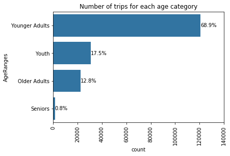

```python
# Choose the first tuple of RGB colors
base_color = sb.color_palette()[0]

sb.countplot(data= df, y='AgeRanges', color=base_color, order=type_order);

# Logic to print the proportion text on the bars
for i in range(len(type_counts)):
    count = type_counts[type_order[i]]
    # Convert count into a percentage, and then into string
    age_string = '{:0.1f}%'.format(100 * count/n_trips)
    # Print the string value on the bar.
    plt.text(count+1, i, age_string, va='center', color = 'black')

plt.title('Number of trips for each age category')
plt.xticks(rotation=90);
plt.xlim([0, 140000]);
```

- According to this visualizes, It's obvious that the most age category has trips is **Younger Adults** with age range **25-40** where **68.9%** of the total trips are a Younger Adult

### What is the most frequent gender type does trips?

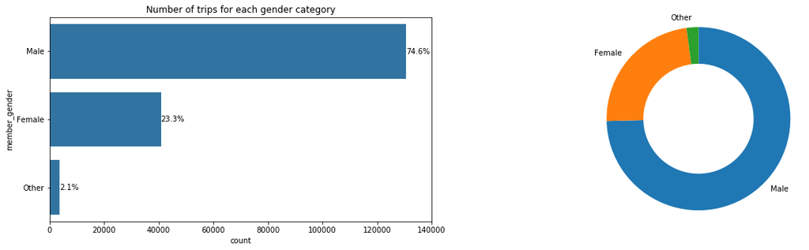

```python
# Resize the chart, and have two plots side-by-side
# Set a larger figure size for subplots
plt.figure(figsize = [20, 5])

# 1 row, 2 cols, subplot 1
plt.subplot(1, 2, 1)
base_color = sb.color_palette()[0]
sb.countplot(data= df, y='member_gender', color=base_color, order=sorted_counts.index);

# Logic to print the proportion text on the bars
for i in range(len(sorted_counts)):
    count = sorted_counts[sorted_counts.index[i]]
    # Convert count into a percentage, and then into string
    age_string = '{:0.1f}%'.format(100 * count/n_trips)
    # Print the string value on the bar.
    plt.text(count+1, i, age_string, va='center', color = 'black')
plt.xlim([0, 140000])
plt.title('Number of trips for each gender category');

plt.subplot(1, 2, 2) # 1 row, 2 cols, subplot 2
plt.pie(sorted_counts, labels =sorted_counts.index, startangle = 90,
        counterclock = False, wedgeprops = {'width' : 0.4});
plt.axis('square');
```

- According to this visualizes, It's obvious that the most gender category has trips is **Male** where **74.6%** of the total trips.

### What is the most time Duration frequence in Seconds?

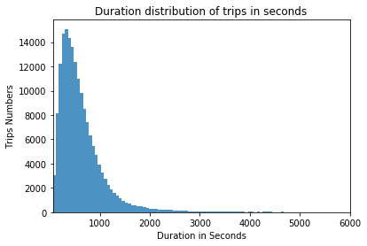

```python
# Distribution of Trip Durations in sconds
bins = np.arange(df['duration_sec'].min(), df['duration_sec'].max()+60, 60)
sb.distplot(df['duration_sec'], bins = bins, kde = False, hist_kws = {'alpha' : 0.8});
plt.title('Duration distribution of trips in seconds')
plt.xlabel('Duration in Seconds')
plt.ylabel('Trips Numbers')
plt.xlim([df['duration_sec'].min(), 6000])
plt.show()
```

- the most time duration frequence in seconds is **300-600** seconds.

### Which days in the week have more trips?

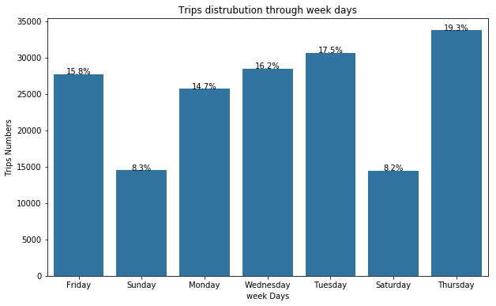

```python
# Distribution of Trip through week days
plt.figure(figsize=[10, 6])
sorted_counts = df['start_time_day_name'].value_counts(sort=False)
n_trips = sorted_counts.sum()

base_color = sb.color_palette()[0]
start_time_day_name_order = df['start_time_day_name'].value_counts(sort=False).index
sb.countplot(data=df, x='start_time_day_name', order=start_time_day_name_order, color=base_color)

# get the current tick locations and labels
locs, labels = plt.xticks()

# loop through each pair of locations and labels
for loc, label in zip(locs, labels):
    # get the text property for the label to get the correct count
    count = sorted_counts[label.get_text()]
    # Convert count into a percentage, and then into string
    age_string = '{:0.1f}%'.format(100 * count/n_trips)
    # Print the string value on the bar.
    plt.text(loc, count+2, age_string, ha = 'center', color = 'black')

plt.xlabel('week Days')
plt.ylabel('Trips Numbers')
plt.title('Trips distrubution through week days');
```

It seems that the number of trips in **(Thursday-Tuesday-Wednesday)** appears to be higher than the number of **(Sunday-Saturday)**.

### what is the Distribution of the trips of each user type pre week?

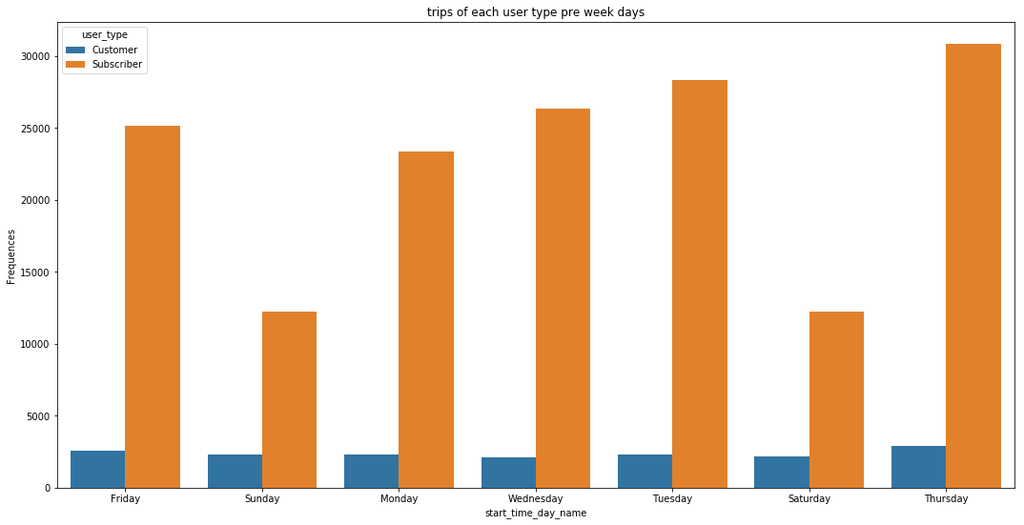

```python
plt.figure(figsize = [18, 9])
start_time_day_name_order = df['start_time_day_name'].value_counts(sort=False).index
sb.countplot(data=df, x='start_time_day_name', hue='user_type', order= start_time_day_name_order);
plt.title('trips of each user type pre week days')
plt.ylabel('Frequences');
```

From the above plot, subscribed users appear to be going on more trips in the all days of the week and most of them are the middle of the week.

### Trips based on Age Categories and weekdays?

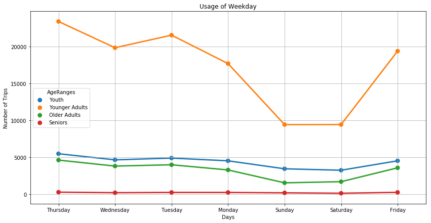

```python
plt.figure(figsize=[14, 7]);

df_classified_user_week = df.groupby(['start_time_day_name', 'AgeRanges']).size().reset_index()
weekday = df.start_time_day_name.unique()

ax = sb.pointplot(data=df_classified_user_week, x='start_time_day_name', y=0, hue = 'AgeRanges', order = weekday);

plt.title('Usage of Weekday');
plt.xlabel('Days')
plt.ylabel('Number of Trips');
plt.grid()
```

- According to the above plot, The "Younger Adults" have the most number of trips through the weekdays, and "Youth" have the second most trips.

### Average duration trips on Weekdays for Member Gender

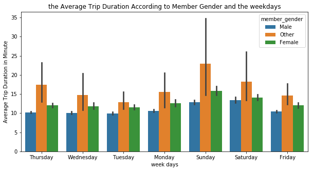

```python
plt.figure(figsize = [10, 5])
df['duration_min'] = (df.duration_sec/60).astype(int)
sb.barplot(data=df, x='start_time_day_name', y='duration_min', hue='member_gender');
plt.xlabel('week days');
plt.ylabel('Average Trip Duration in Minute');
plt.title('the Average Trip Duration According to Member Gender and the weekdays');
```

- The **Other** members gender has the most average duration trips throughout all weekdays.

Conclusions:

1. the most age category has trips is Younger Adults with age range **25-40** where **68.9%** of the total trips are a Younger Adult.
2. the most gender category has trips is Male where **74.6%** of the total trips.
3. Most trip times are between **300-600** secondslong (mostly between 5 and 10 minutes).
4. the number of trips in (Thursday-Tuesday-Wednesday) appears to be higher than the number of (Sunday-Saturday).
5. subscribed users appear to be going on more trips in the all days of the week and most of them are the middle of the week.
6. The "Younger Adults" have the most number of trips through the weekdays, and "Youth" have the second most trips.
7. The Other members gender has the most average duration trips throughout all weekdays.